# Red Red Wine by Laura Yoshizawa

# Data Source

This is a data analysis of red wine samples, captured by Paulo Cortez, Antonio Cerdeira, Fernando Almeida, Telmo Matos and Jose Reis. Red Wines were analyzed on their physical qualities (chlorides, pH, alcohol by volume, etc…), and subjectively measured by wine experts.

# Univariate Plots

```
## [1] 1599   13
```

```
## 'data.frame':    1599 obs. of  13 variables:
##  $ X                   : int  1 2 3 4 5 6 7 8 9 10 ...
##  $ fixed.acidity       : num  7.4 7.8 7.8 11.2 7.4 7.4 7.9 7.3 7.8 7.5 ...
##  $ volatile.acidity    : num  0.7 0.88 0.76 0.28 0.7 0.66 0.6 0.65 0.58 0.5 ...
##  $ citric.acid         : num  0 0 0.04 0.56 0 0 0.06 0 0.02 0.36 ...
##  $ residual.sugar      : num  1.9 2.6 2.3 1.9 1.9 1.8 1.6 1.2 2 6.1 ...
##  $ chlorides           : num  0.076 0.098 0.092 0.075 0.076 0.075 0.069 0.065 0.073 0.071 ...
##  $ free.sulfur.dioxide : num  11 25 15 17 11 13 15 15 9 17 ...
##  $ total.sulfur.dioxide: num  34 67 54 60 34 40 59 21 18 102 ...
##  $ density             : num  0.998 0.997 0.997 0.998 0.998 ...
##  $ pH                  : num  3.51 3.2 3.26 3.16 3.51 3.51 3.3 3.39 3.36 3.35 ...
##  $ sulphates           : num  0.56 0.68 0.65 0.58 0.56 0.56 0.46 0.47 0.57 0.8 ...
##  $ alcohol             : num  9.4 9.8 9.8 9.8 9.4 9.4 9.4 10 9.5 10.5 ...
##  $ quality             : int  5 5 5 6 5 5 5 7 7 5 ...
```

This dataset features 12 qualities of 1599 different red wines. A thirteenth variable, ‘X’, is also listed, but it appears to be an index number for each wine. All values within this dataset are numerical.

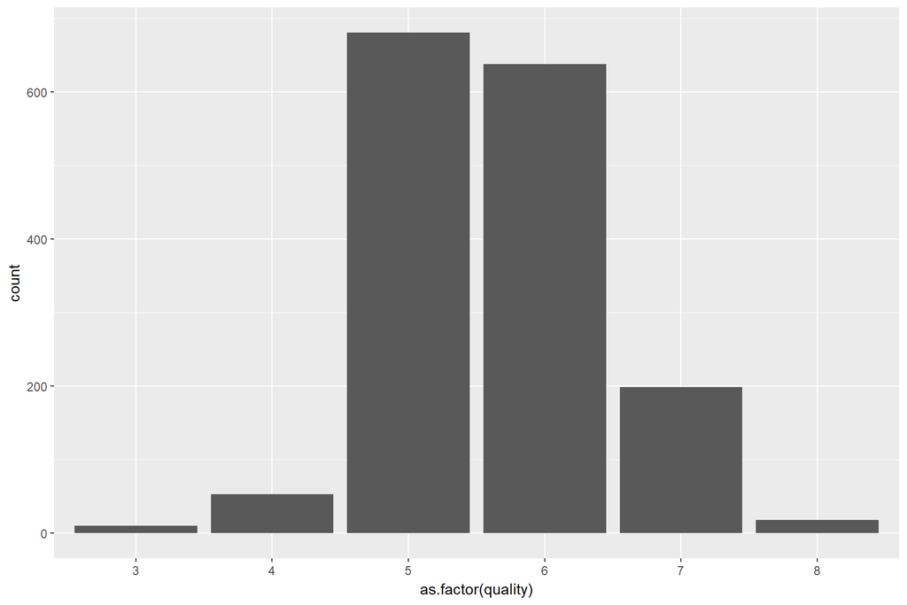

```
##    Min. 1st Qu.  Median    Mean 3rd Qu.    Max.
##   3.000   5.000   6.000   5.636   6.000   8.000
```

The quality scale was from 0 to 10, 0 being the worst and 10 being the best.  
The majority of the wines were given a score of 5 or 6. Only a few wines were given a score of 3, with none scoring lower. A few wines were also given a score of 8, with none scoring higher. No wines were given an exceptional or terrible rating, leading to this chart reflecting a normal distribution of quality.

Lets take a look at the physical properties of these wines.

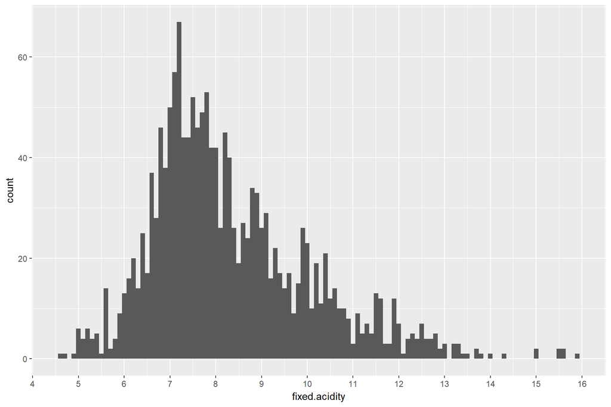

```
##    Min. 1st Qu.  Median    Mean 3rd Qu.    Max.
##    4.60    7.10    7.90    8.32    9.20   15.90
```

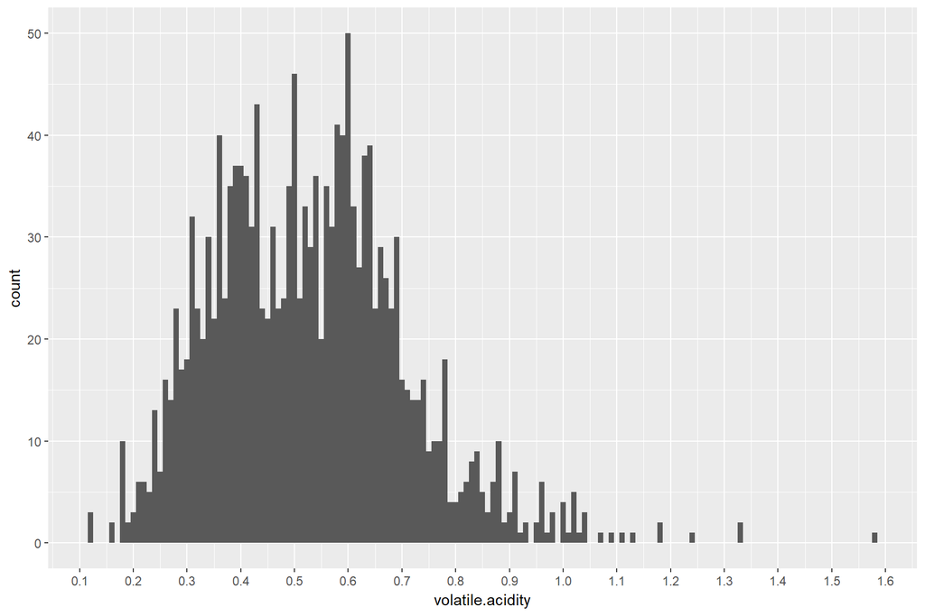

```
##    Min. 1st Qu.  Median    Mean 3rd Qu.    Max.
##  0.1200  0.3900  0.5200  0.5278  0.6400  1.5800
```

The histogram for volatile acidity and summary statistics also shows a positive skew, however there appear to be less outliers compared to fixed acidity.

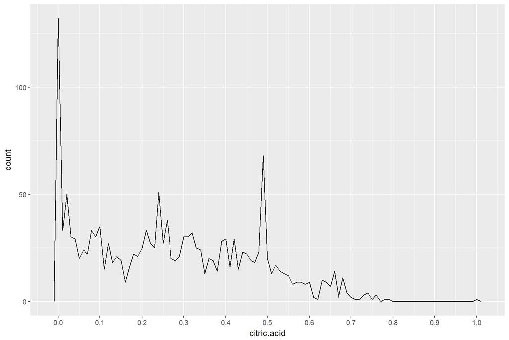

```
##    Min. 1st Qu.  Median    Mean 3rd Qu.    Max.
##   0.000   0.090   0.260   0.271   0.420   1.000
```

All of the wines have some fixed acidity and volatile acidity. However over 100 of the samples contain no citric acid. The citric acid frequency polygon indicates a multi-modal distribution, with peaks around 0, 0.25, and 0.5 g/dm^3.

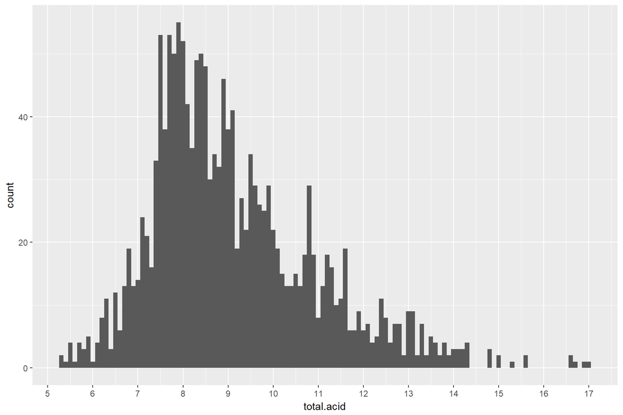

```
##    Min. 1st Qu.  Median    Mean 3rd Qu.    Max.
##   5.270   7.827   8.720   9.118  10.070  17.050
```

The values of the three types of acid were summed up under a new variable: total acid.

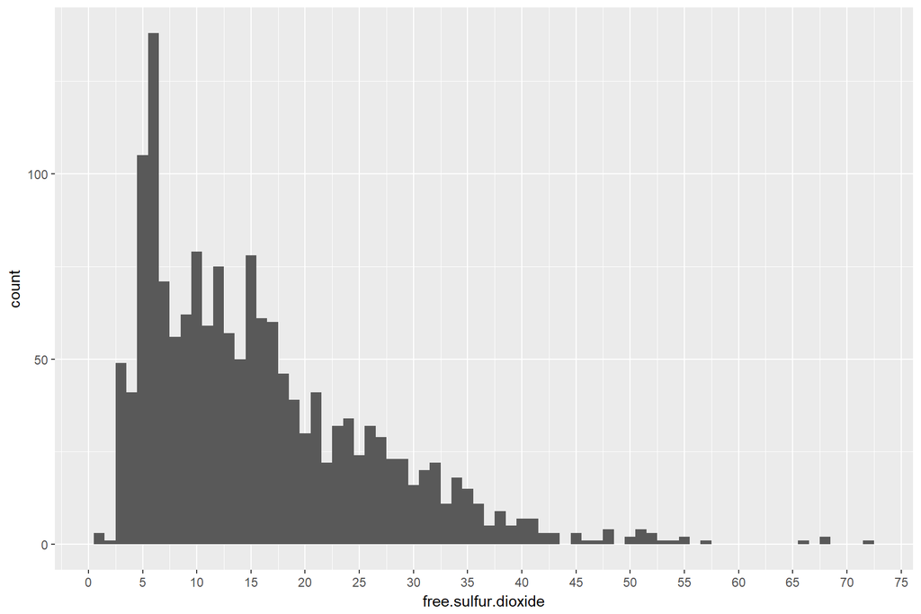

```
##    Min. 1st Qu.  Median    Mean 3rd Qu.    Max.
##    1.00    7.00   14.00   15.87   21.00   72.00
```

This histogram for free sulfur dioxide is positively skewed with a long tail. As the 3rd quartile is 21 and the max is 72, there is a large range in the highest quartile of values. The chart indicates a number of outliers above 40.

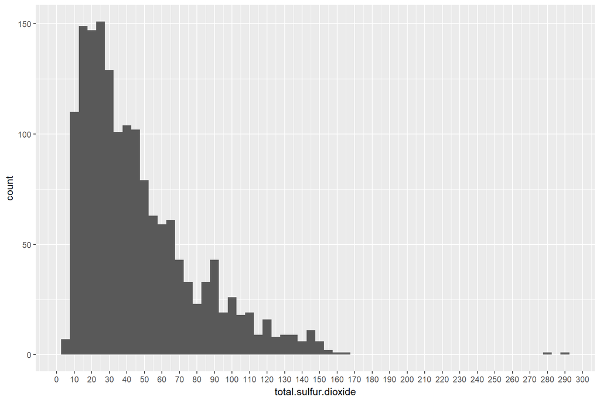

```
##    Min. 1st Qu.  Median    Mean 3rd Qu.    Max.
##    6.00   22.00   38.00   46.47   62.00  289.00
```

This histogram for total sulfur dioxide shows a positively skewed distribution. There are a few extreme outliers over 280.

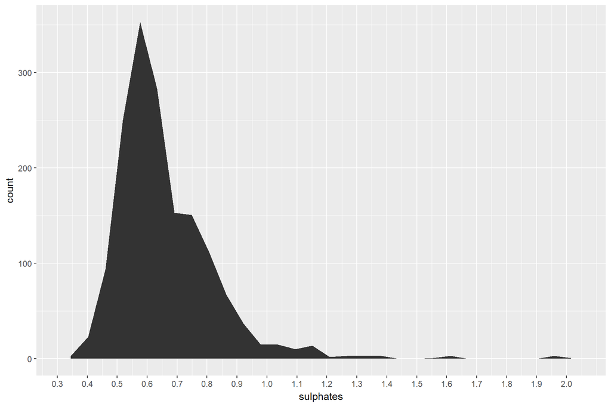

```
##    Min. 1st Qu.  Median    Mean 3rd Qu.    Max.
##  0.3300  0.5500  0.6200  0.6581  0.7300  2.0000
```

This sulphates area plot shows the majority of the values are between 0.5 and 0.9, with a few over 1.5 g/dm^3.

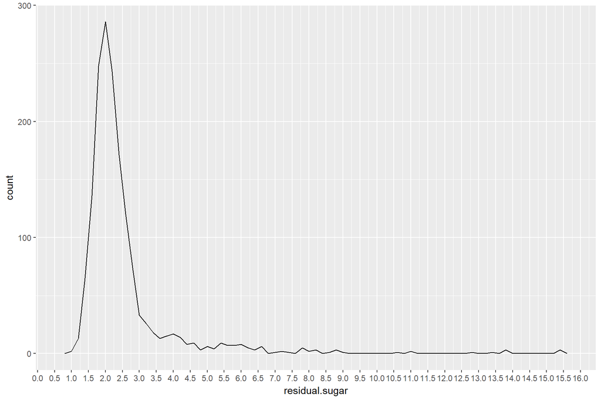

```
##    Min. 1st Qu.  Median    Mean 3rd Qu.    Max.
##   0.900   1.900   2.200   2.539   2.600  15.500
```

This frequency polygon for ersidual sugar shows a very long tail, with the majority of wines having between 1 and 3 grams/dm^3. The long tail pulls the average residual sugar content to almost the third quartile.

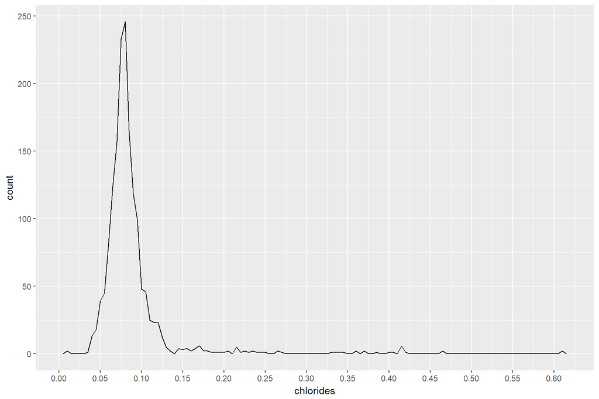

```
##    Min. 1st Qu.  Median    Mean 3rd Qu.    Max.
## 0.01200 0.07000 0.07900 0.08747 0.09000 0.61100
```

This chlorides frequency polygon also shows a very long tail. The majority of the chlorides in the wines is between 0.05 and 0.10. Similar to residual sugar, the mean value is almost at the third quartile.

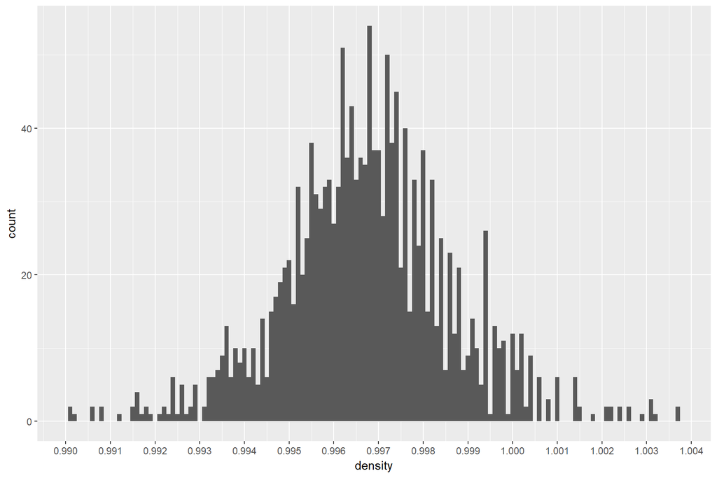

```
##    Min. 1st Qu.  Median    Mean 3rd Qu.    Max.
##  0.9901  0.9956  0.9968  0.9967  0.9978  1.0040
```

This histogram for the density of the wines shows a normal distribution.

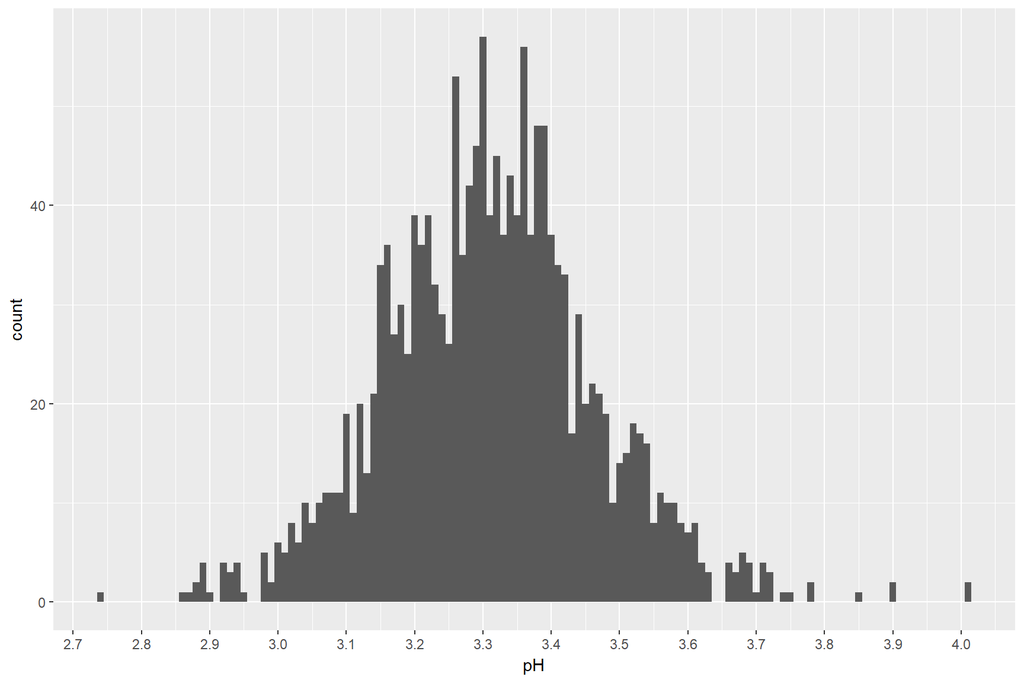

```
##    Min. 1st Qu.  Median    Mean 3rd Qu.    Max.
##   2.740   3.210   3.310   3.311   3.400   4.010
```

This histogram showing the pH of the wines shows a normal distribution, with a few outliers aaround 2.75, 3.9, and 4.0

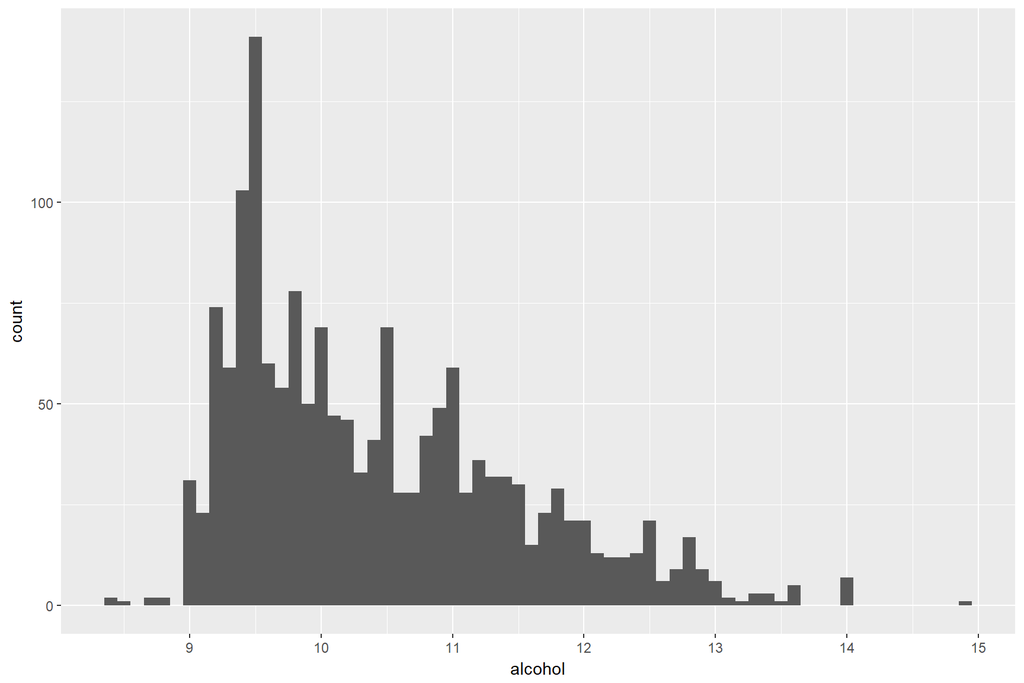

```
##    Min. 1st Qu.  Median    Mean 3rd Qu.    Max.
##    8.40    9.50   10.20   10.42   11.10   14.90
```

The histogram for alcohol is positively skewed, with half of the values being between 9.5 and 11.10%.

# Univariate Analysis

**Dataset Structure**

This dataset is composed of 1599 red wines with 12 features: fixed acidity, volatile acidity, citric acid, residual sugar, chlorides, free sulfur dioxide, total sulfur dioxide, density, pH, sulphates, alcohol, and quality. With the exception of quality, all of the features reflect the chemical composition of the wine, and the values are stored numerically. The quality variable was determined subjectively by a panel of three wine experts, with the median score being taken. This value is stored as an integer.

There is a variable named ‘X’, which is an index number for the wine. This variable has been removed from the dataset.

**Main Features**

The main feature of interest within the dataset is the quality. This is because it is the only subjective variable, and is determined by the aroma and taste of the wine. The other features are properties that alter the smell and taste, which can affect the quality grade.

**Supporting Features**

I think that the acidity values (fixed, volatile, and citric) and the sulfur values (free sulfur dioxide, total sulfur dioxide, and sulphates) will support my investigation into the quality the most since those will impact the smell and taste of the wines the most.

**New Variables**

The total.acid variable was created which is the sum of fixed acid, volatile acid, and citric acid. This is because I want to know if any particular acid affects the quality of the wine, or if it is the total amount of acid within the wine, regardless of type.

**Plot Adjustments**

A univariate examination was conducted on all features, and no operations were performed to adjust the data. This is because I wanted to see whe whole set of data, including the outliers, since the irregularities could contribute to the overall quality of the wine.

# Bivariate Plots Section

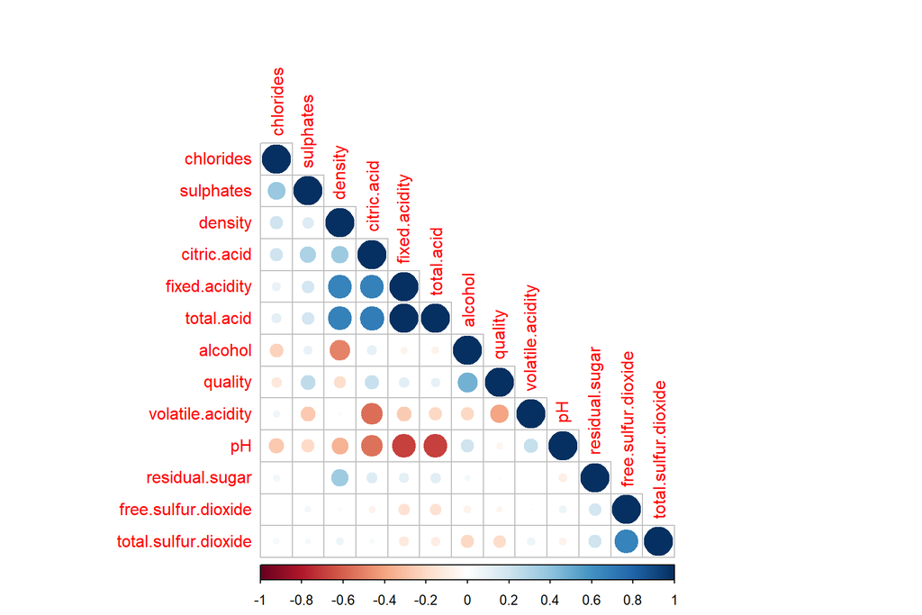

From the correlation plot above, a few things stand out. The negative correlation between the acids and pH makes sense, because more acid will result in a lower pH. The positve correlation between free sulfur dioxide and total sulfur dioxide also makes sense, because free sulfur dioxide is a component of total sulfur dioxide.

Lets dive deeper into the correlations between quality and alcohol, volatile acidity, citric acid, and sulphates.

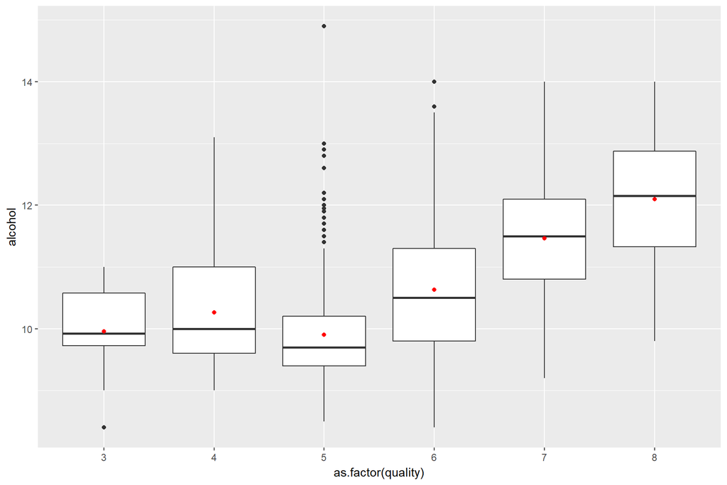

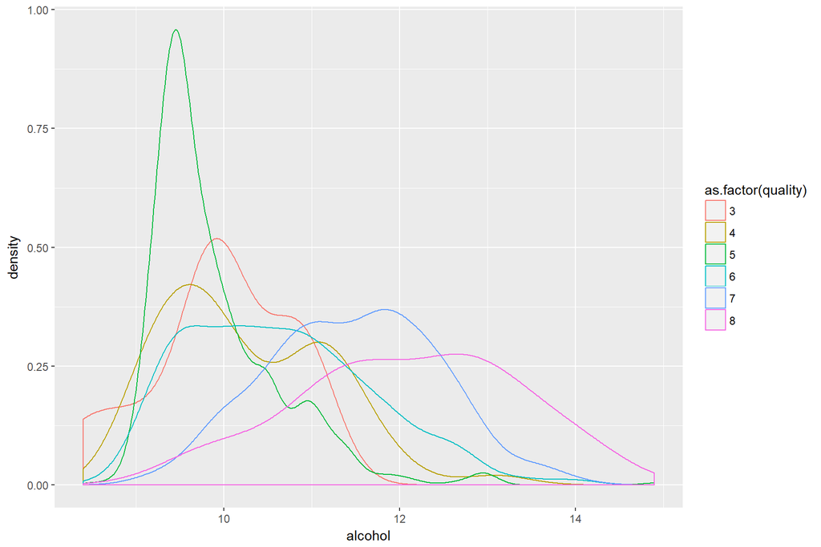

These plots look at alcohol content compared to quality. The first chart is a boxplot showing the central tendency of alcohol for the different quality grades. The second chart shows the kernel density of alcohol by quality. It appears that higher quality wines have a higher alcohol content.

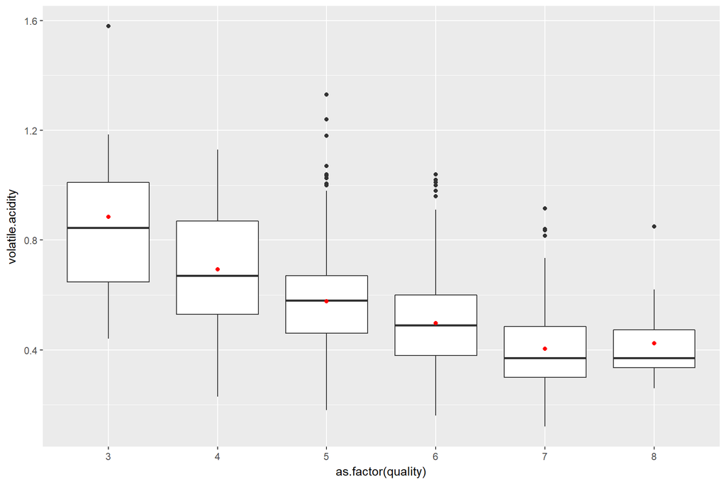

```
## wine$quality: 3
##    Min. 1st Qu.  Median    Mean 3rd Qu.    Max.
##  0.4400  0.6475  0.8450  0.8845  1.0100  1.5800
## --------------------------------------------------------
## wine$quality: 4
##    Min. 1st Qu.  Median    Mean 3rd Qu.    Max.
##   0.230   0.530   0.670   0.694   0.870   1.130
## --------------------------------------------------------
## wine$quality: 5
##    Min. 1st Qu.  Median    Mean 3rd Qu.    Max.
##   0.180   0.460   0.580   0.577   0.670   1.330
## --------------------------------------------------------
## wine$quality: 6
##    Min. 1st Qu.  Median    Mean 3rd Qu.    Max.
##  0.1600  0.3800  0.4900  0.4975  0.6000  1.0400
## --------------------------------------------------------
## wine$quality: 7
##    Min. 1st Qu.  Median    Mean 3rd Qu.    Max.
##  0.1200  0.3000  0.3700  0.4039  0.4850  0.9150
## --------------------------------------------------------
## wine$quality: 8
##    Min. 1st Qu.  Median    Mean 3rd Qu.    Max.
##  0.2600  0.3350  0.3700  0.4233  0.4725  0.8500
```

This trend reflects an increasing quality with decreasing volatile acidity.

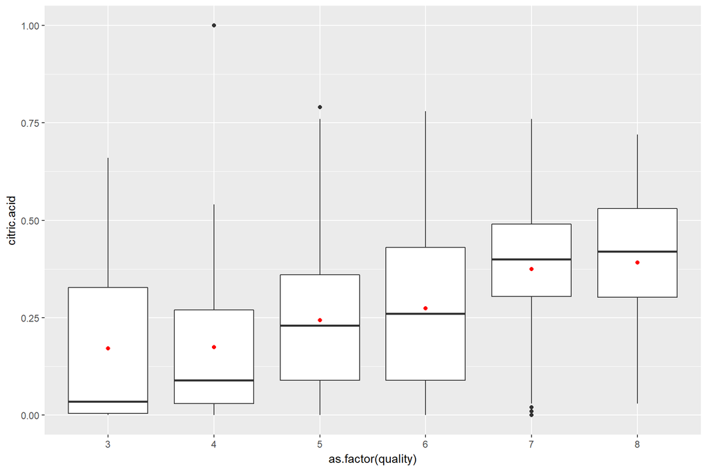

```
## wine$quality: 3
##    Min. 1st Qu.  Median    Mean 3rd Qu.    Max.
##  0.0000  0.0050  0.0350  0.1710  0.3275  0.6600
## --------------------------------------------------------
## wine$quality: 4
##    Min. 1st Qu.  Median    Mean 3rd Qu.    Max.
##  0.0000  0.0300  0.0900  0.1742  0.2700  1.0000
## --------------------------------------------------------
## wine$quality: 5
##    Min. 1st Qu.  Median    Mean 3rd Qu.    Max.
##  0.0000  0.0900  0.2300  0.2437  0.3600  0.7900
## --------------------------------------------------------
## wine$quality: 6
##    Min. 1st Qu.  Median    Mean 3rd Qu.    Max.
##  0.0000  0.0900  0.2600  0.2738  0.4300  0.7800
## --------------------------------------------------------
## wine$quality: 7
##    Min. 1st Qu.  Median    Mean 3rd Qu.    Max.
##  0.0000  0.3050  0.4000  0.3752  0.4900  0.7600
## --------------------------------------------------------
## wine$quality: 8
##    Min. 1st Qu.  Median    Mean 3rd Qu.    Max.
##  0.0300  0.3025  0.4200  0.3911  0.5300  0.7200
```

This trend reflects increasing quality with increasing amounts of citric acid. It is interesting that for wines of quality 3 and 4, the mean is substantially different from the median values.

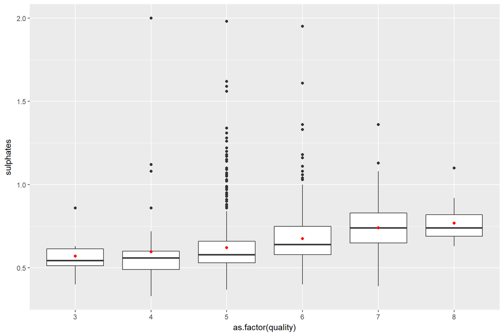

```
## wine$quality: 3
##    Min. 1st Qu.  Median    Mean 3rd Qu.    Max.
##  0.4000  0.5125  0.5450  0.5700  0.6150  0.8600
## --------------------------------------------------------
## wine$quality: 4
##    Min. 1st Qu.  Median    Mean 3rd Qu.    Max.
##  0.3300  0.4900  0.5600  0.5964  0.6000  2.0000
## --------------------------------------------------------
## wine$quality: 5
##    Min. 1st Qu.  Median    Mean 3rd Qu.    Max.
##   0.370   0.530   0.580   0.621   0.660   1.980
## --------------------------------------------------------
## wine$quality: 6
##    Min. 1st Qu.  Median    Mean 3rd Qu.    Max.
##  0.4000  0.5800  0.6400  0.6753  0.7500  1.9500
## --------------------------------------------------------
## wine$quality: 7
##    Min. 1st Qu.  Median    Mean 3rd Qu.    Max.
##  0.3900  0.6500  0.7400  0.7413  0.8300  1.3600
## --------------------------------------------------------
## wine$quality: 8
##    Min. 1st Qu.  Median    Mean 3rd Qu.    Max.
##  0.6300  0.6900  0.7400  0.7678  0.8200  1.1000
```

These box plots show an increase in quality with an increase in sulphates. An interesting point to note is how small the IQR is compared to the overall range of the dataset. Ther is also a large number of outliers for wines of quality 4, 5, and 6. For wines of quality 4, the outliers are so large that it skews the average sulphate amount to almost the third quartile.

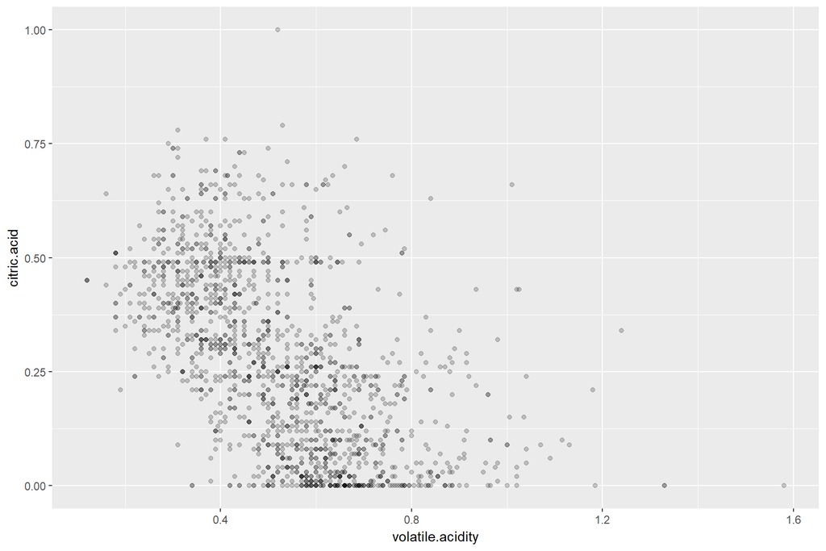

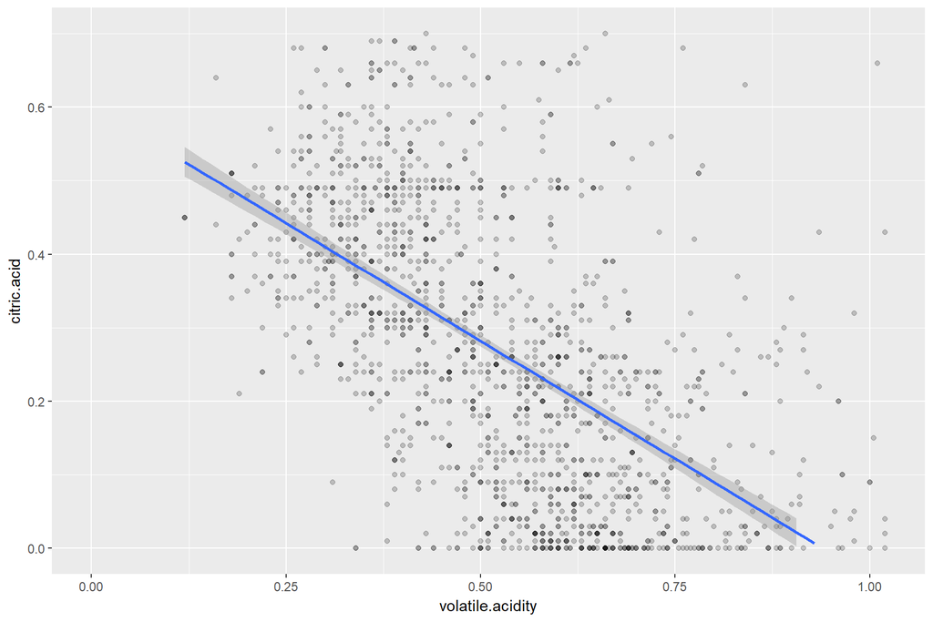

This scatter plot looks at the relationship between volatile acidity and citric acid. As volatile acidity increases, citric acid decreases. The trendline shows the negative relationship.

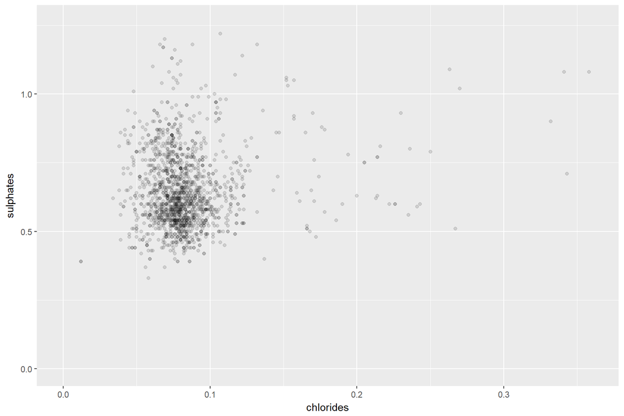

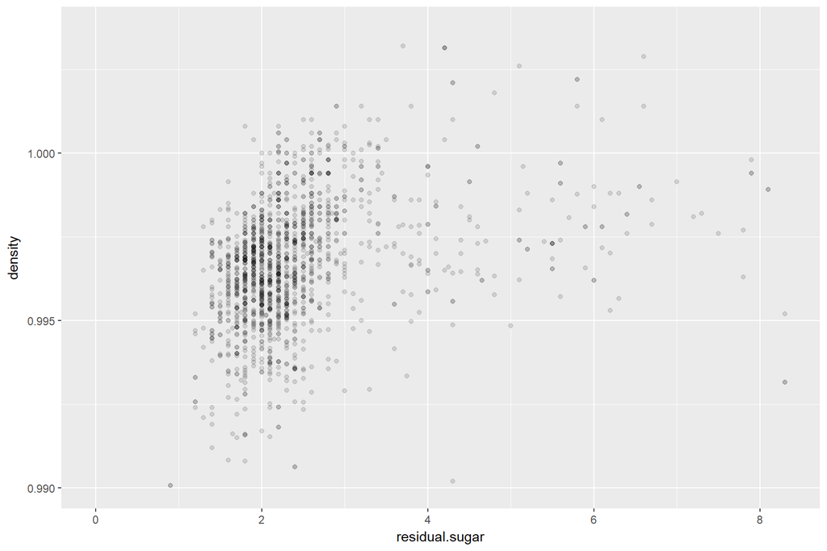

As the corrplot above indicates there may be a mild correlation between chlorides and sulphates, and between residual sugar and density, the above pairs were plotted to see the relationships. While the majority of the data is clustered together, there does not appear to be a correlation between the features.

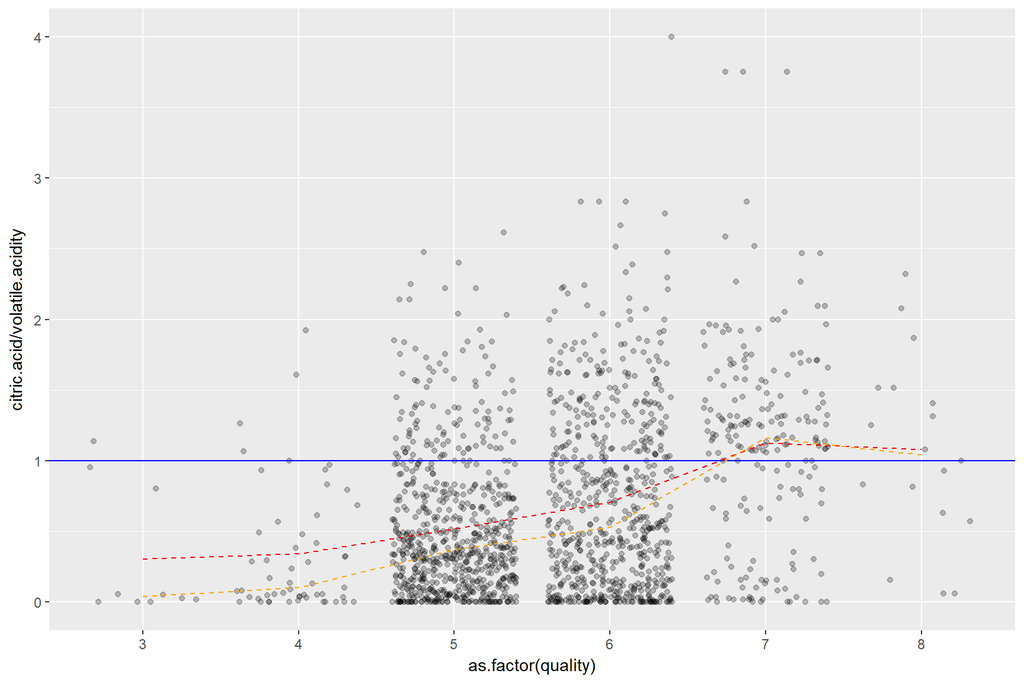

This plot looks at the ratio of citric acid and volatile acidity and compares it to the quality of the wine. It looks like as the ratio goes up, the quality also goes up, however this is not reflected in the highest quality rated wines. The red line shows the average ratios for each quality grade, and the orange line shows the median ratio for each qualilty grade.

# Bivariate Analysis

**Relationships with Quality**

The quality of the wine was correlated the most with alcohol content at 0.48.  
As the alcohol content increased in the wine, the quality increased as well. The average alcohol content of the worst rated wines was 9.955%, and the average alcohol content of the hgiehst rating wines was 12.09%.

Volatile acidity had an inverse correlation with quality, -0.39, with the lowest quality wines having a volatile acidity average of .8845. The highest quality wines had a volatile acidity of .4233. This relationship is expected, as volatile acid is defined as “the amount of acetic acid in wine, which at too high of levels can lead to an unpleasant, vinegar taste.”

Citric Acid has a small correlation with quality, with a correlation coefficient of 0.23. The median value for the worst quality wines was 0.035, and the median value for the highest quality wines was 0.42. This relationship is expected, as citric acid is described as “found in small quantities, citric acid can add ‘freshness’ and flavor to wines.”

Sulphates also has a small positvie correlation with quality, with a correlation coefficient of 0.25. The median value for the worst quality wines was 0.5450, and the median value for the highest quality wines was 0.74. Sulphates are described as “a wine additive which can contribute to sulfur dioxide gas (S02) levels, wich acts as an antimicrobial and antioxidant.”

**Interesting Relationships**

I thought it was interesting how Citric Acid and Volatile Acidity are inversely correlated. In addition to the correlation between Citric Acid and Quality and Volatile Acidity and Quality, I also looked at the ratio of Citric Acid and Volatile Acidity to Quality. Because increasing Citric Acid was correlated to an increase in Quality, but an increase in Volatile Acidity was negatively correlated to Quality, I was curious if a higher Citric Acid to Volatile Acidity ratio was correlated with an increase in quality.

The majority of wines in the dataset have more volatile acidity than citric acid, but as the ratio increases, the quality goes up. The mean and median wines for the highest quality ratings (7 and 8), have a ratio greater than 1.

**Strongest Correlations**

- -0.68 fixed acidity and pH
- 0.67 fixed acidity and citric acid
- 0.67 fixed acidity and density
- 0.67 free sulfur dioxide and total sulfur dioxide

Because free sulfur dioxide is included in total sulfur dioxide, this strong relationship is expected.

# Multivariate Plots Section

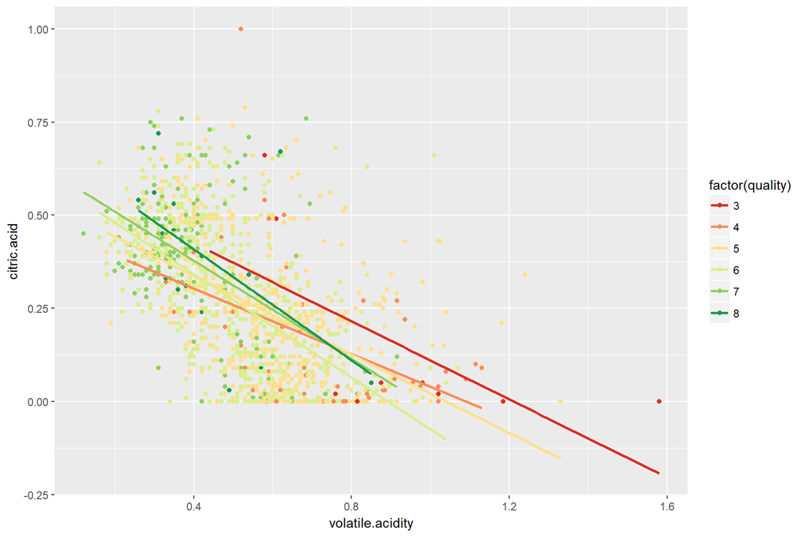

Here’s another comparison of citric acid to volatile acidity, colored by quality.

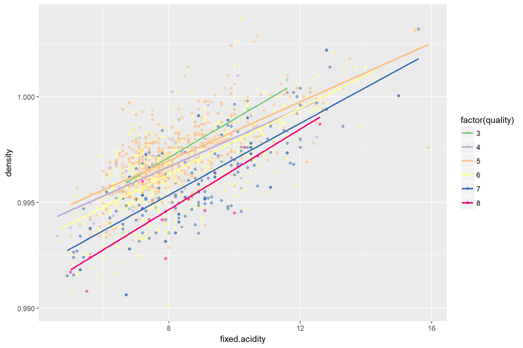

As fixed acidity increases, density increases as well. It also appears that quality is impacted by this relationship, as the least dense wines within a specific level of fixed acidity are given higher quality ratings.

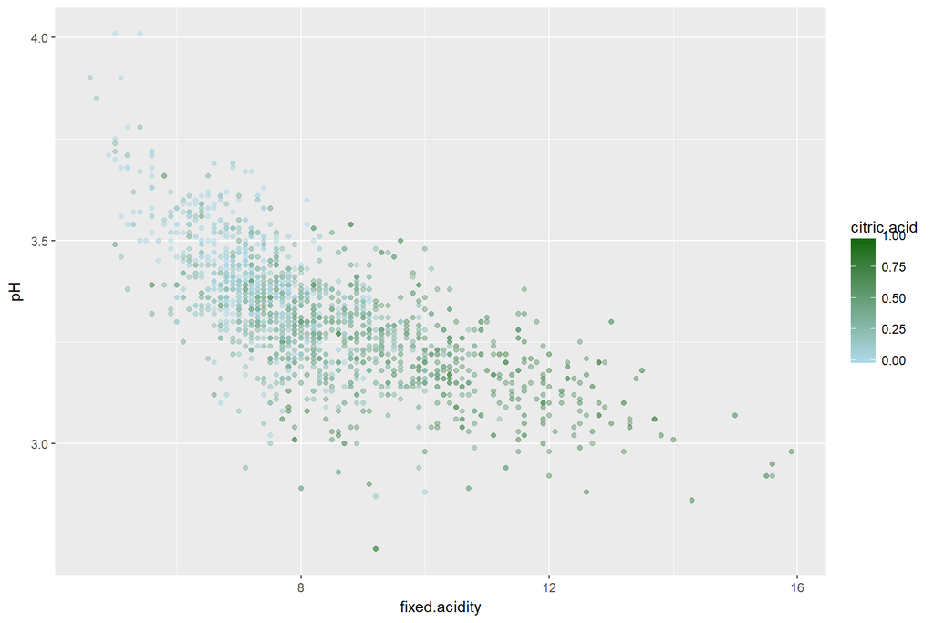

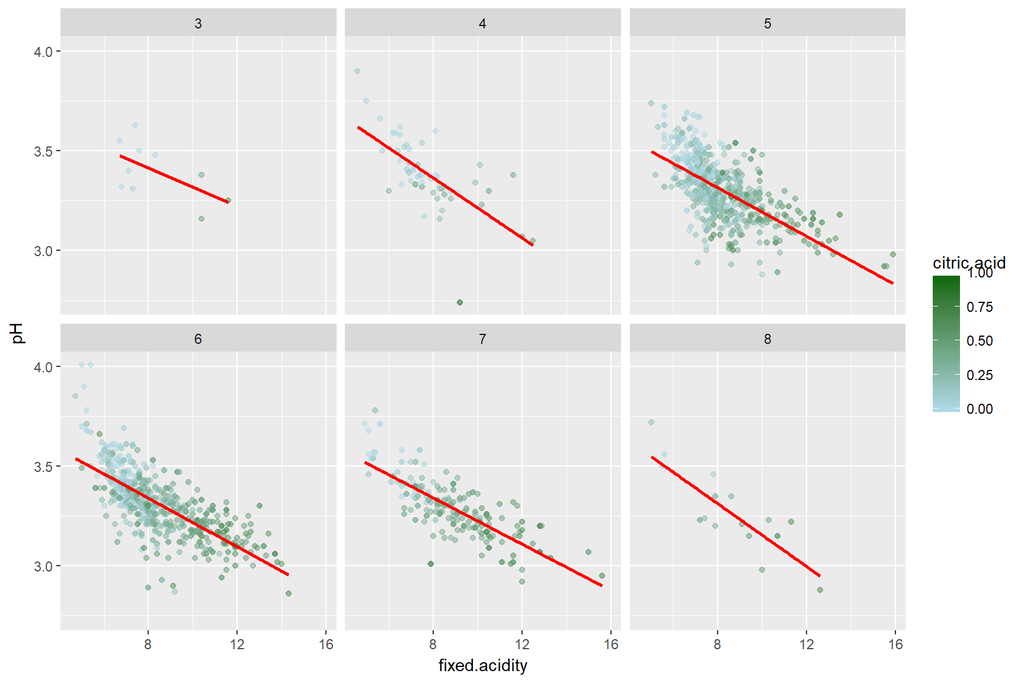

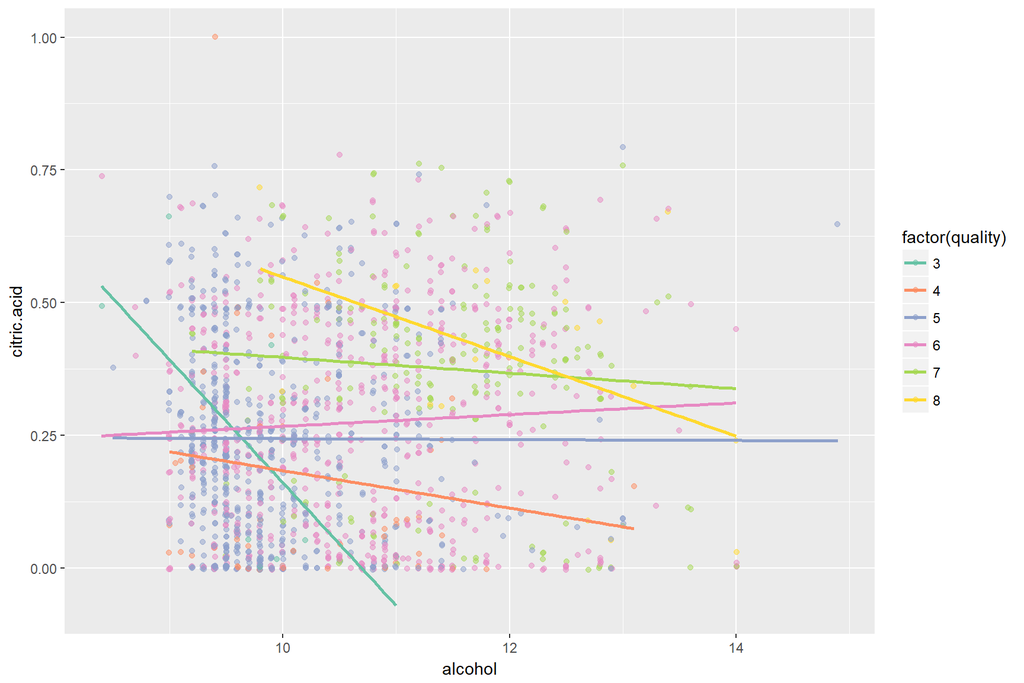

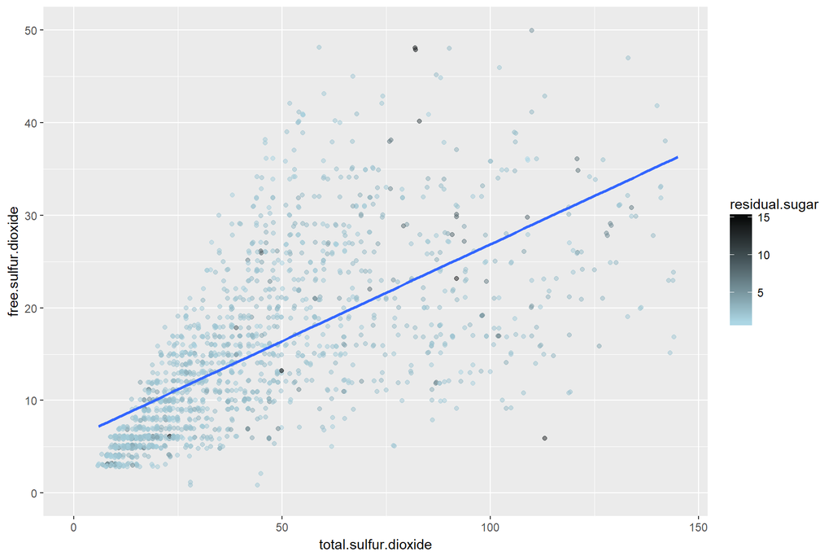

This plot looks at free sulfur dioxide, total sulfur dioxide, and the levels of residual sugar. Free sulfur dioxide is a component of total sulfur dioxide, and the positive correlation is apparent. When colored by residual sugar, it appears that the wines with higher amounts of residual sugar contain more total sulfur dioxide and free sulfur dioxide.

# Multivariate Analysis

**Relationships with Quality** In the Bivariate analysis, I explored the relationship between citric acid and volatile acid and how they impact quality. In this multivariate analysis, I explored this even further.

The highest quality wines not only have a higher citric acid to volatile acidity ratio, but also a lower density to fixed acidity ratio as well.

Additionally, while citric acid and alcohol content within the wines did not appear to have any correlation, it became apparent that citric acid and alcohol are both significant factors when comparing between quality. On the last chart, it shows that higher quality wines not noly have the higher alcohol content, but higher amounts of citric acid as well.

**Other Relationships** From the bivariate analysis, the fixed acidity had a strong correlation coefficient with pH, citric acid, and density, so I looked into these relationships a bit more.

As fixed acidity increased, pH decreased and citric acid increased. When faceted by quality, it didn’t appear that the fixed acidity and pH had any substantial influence on the quality. This is further substantiated by the correlation grid from the Bivariate analysis.

# Final Plots and Summary

### Alcohol by Quality

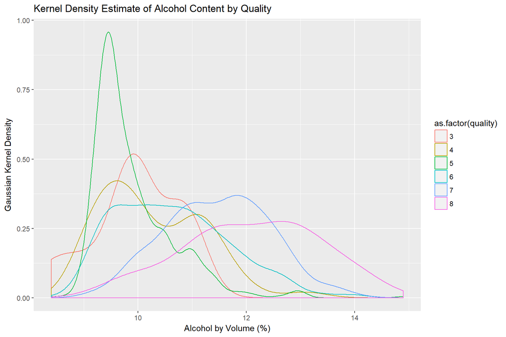

Plot One looks at the relationship between Alcohol by Volume and Quality. As alcohol content was the factor that had the strongest correlation with quality, this plot shows the kernel density of alcohol volume, colored by quality. As you can see in the plot, the lowest quality wines have the highest kernel density under 11% Alcohol by Volume, while the highest quality wines have the highest kernel density over 11%. This shows a trend that more high quality wines have higher amounts of alcohol.

### Fixed Acidity and Density

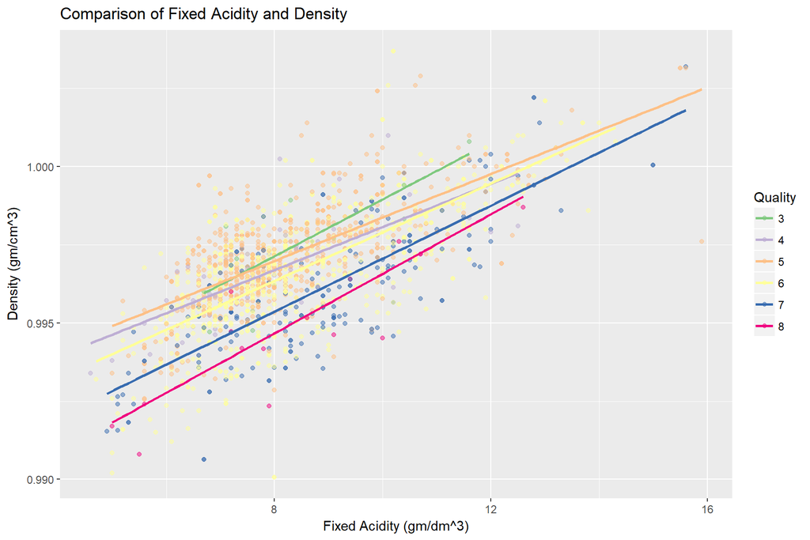

This plot looks at the relationship of Density and Fixed Acidity, and colors it by quality. Fixed acidity and density have a positive correlation, and when looking at the wine quality on the plot, an interesting observation is made: while the the trendlines for each quality level appears to have roughly the same slope, the y-intercept decreases with quality. This means that higher quality wines are less dense when compared to other wines with the same amounts of fixed acidity.